# Assignment3-Natta-HotelBookingDemand

# Data Exploration:

## Plot-1

### Total percentage of repeated guests vs non repeated guests:

-Interpretation using Pie chart: as per below pie chart, 96.8% are not repeated guests and only 3.19% are repeated guests

```r
df %>% group_by(is_repeated_guest) %>%
  count(is_repeated_guest) %>%
  summarise(percent = (n/nrow(df))*100 , total=n)
```

```
# A tibble: 2 x 3
  is_repeated_guest percent  total
  <fct>               <dbl>  <int>
1 0                   96.8  115580
2 1                    3.19   3810
```

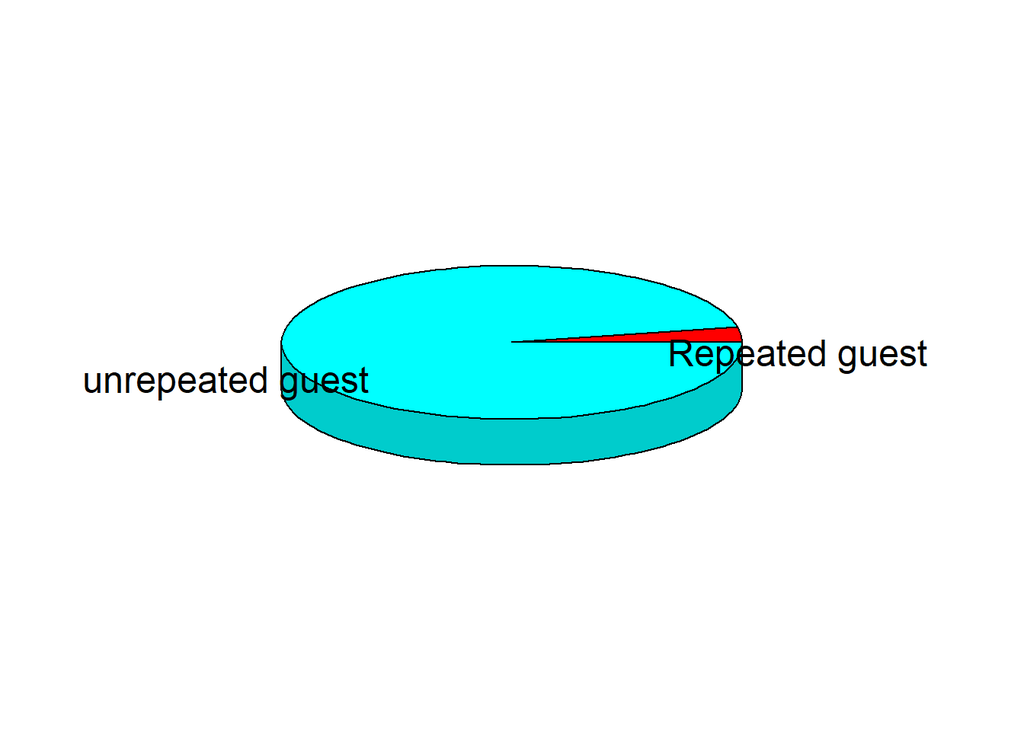

```r
a<-sum(df$is_repeated_guest == "1" )
b<-sum(df$is_repeated_guest == "0")
stats <- c(a,b)
label<- c("Repeated guest", "unrepeated guest")
require(plotrix)
pie3D(stats,labels=label)
```

# Data Visualizations:

## Plot-2

### Plot for adults stayed at weekends based on customer type:

### Interpretation:

- so from the graph, it says about adults who stayed at weekends based on customer_type over years 2015-2017
- In the year 2015, customer type - transient are more and group being less.
- comparing all the years, customer_type - transient dominated other types

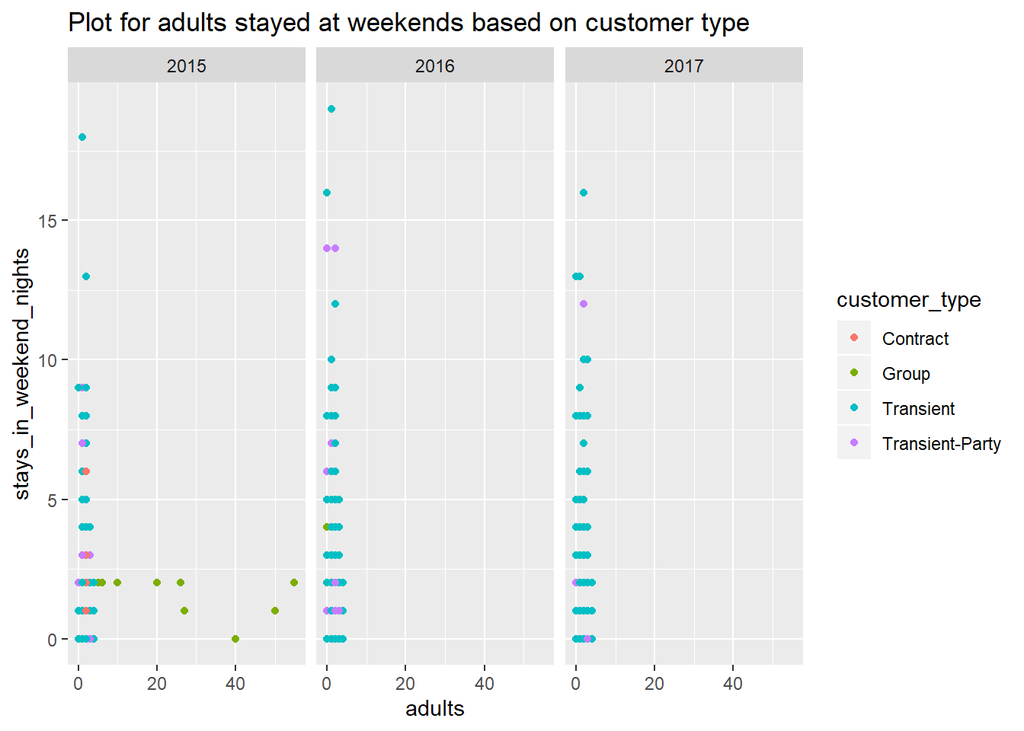

```r
ggplot(data = df) + geom_point(mapping = aes(x = adults, y = stays_in_weekend_nights, color = customer_type ))+
  facet_wrap(~arrival_date_year)+
  ggtitle("Plot for adults stayed at weekends based on customer type")
```